# Homework 19013

19013

2019-12-31

# Homework 1

## Question

Use knitr to produce at least 3 examples (texts, ﬁgures, tables).

## Answer

### the first example(text)

You can get many knowledge about R from this class.But you must spend a lot of time in it.In this way,you will get well command of R and maybe become an expert in R.

### the second example(figure)

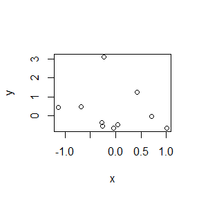

```r
x<-rnorm(10,mean = 0,sd=1)
y<-rnorm(10,mean = 0,sd=1)
plot(x,y)
```

### the third example(table)

```r
knitr::kable(mtcars)
```

|  | mpg | cyl | disp | hp | drat | wt | qsec | vs | am | gear | carb |
| --- | --- | --- | --- | --- | --- | --- | --- | --- | --- | --- | --- |
| Mazda RX4 | 21.0 | 6 | 160.0 | 110 | 3.90 | 2.620 | 16.46 | 0 | 1 | 4 | 4 |
| Mazda RX4 Wag | 21.0 | 6 | 160.0 | 110 | 3.90 | 2.875 | 17.02 | 0 | 1 | 4 | 4 |
| Datsun 710 | 22.8 | 4 | 108.0 | 93 | 3.85 | 2.320 | 18.61 | 1 | 1 | 4 | 1 |
| Hornet 4 Drive | 21.4 | 6 | 258.0 | 110 | 3.08 | 3.215 | 19.44 | 1 | 0 | 3 | 1 |
| Hornet Sportabout | 18.7 | 8 | 360.0 | 175 | 3.15 | 3.440 | 17.02 | 0 | 0 | 3 | 2 |
| Valiant | 18.1 | 6 | 225.0 | 105 | 2.76 | 3.460 | 20.22 | 1 | 0 | 3 | 1 |
| Duster 360 | 14.3 | 8 | 360.0 | 245 | 3.21 | 3.570 | 15.84 | 0 | 0 | 3 | 4 |
| Merc 240D | 24.4 | 4 | 146.7 | 62 | 3.69 | 3.190 | 20.00 | 1 | 0 | 4 | 2 |
| Merc 230 | 22.8 | 4 | 140.8 | 95 | 3.92 | 3.150 | 22.90 | 1 | 0 | 4 | 2 |
| Merc 280 | 19.2 | 6 | 167.6 | 123 | 3.92 | 3.440 | 18.30 | 1 | 0 | 4 | 4 |
| Merc 280C | 17.8 | 6 | 167.6 | 123 | 3.92 | 3.440 | 18.90 | 1 | 0 | 4 | 4 |
| Merc 450SE | 16.4 | 8 | 275.8 | 180 | 3.07 | 4.070 | 17.40 | 0 | 0 | 3 | 3 |
| Merc 450SL | 17.3 | 8 | 275.8 | 180 | 3.07 | 3.730 | 17.60 | 0 | 0 | 3 | 3 |
| Merc 450SLC | 15.2 | 8 | 275.8 | 180 | 3.07 | 3.780 | 18.00 | 0 | 0 | 3 | 3 |
| Cadillac Fleetwood | 10.4 | 8 | 472.0 | 205 | 2.93 | 5.250 | 17.98 | 0 | 0 | 3 | 4 |
| Lincoln Continental | 10.4 | 8 | 460.0 | 215 | 3.00 | 5.424 | 17.82 | 0 | 0 | 3 | 4 |
| Chrysler Imperial | 14.7 | 8 | 440.0 | 230 | 3.23 | 5.345 | 17.42 | 0 | 0 | 3 | 4 |
| Fiat 128 | 32.4 | 4 | 78.7 | 66 | 4.08 | 2.200 | 19.47 | 1 | 1 | 4 | 1 |
| Honda Civic | 30.4 | 4 | 75.7 | 52 | 4.93 | 1.615 | 18.52 | 1 | 1 | 4 | 2 |
| Toyota Corolla | 33.9 | 4 | 71.1 | 65 | 4.22 | 1.835 | 19.90 | 1 | 1 | 4 | 1 |
| Toyota Corona | 21.5 | 4 | 120.1 | 97 | 3.70 | 2.465 | 20.01 | 1 | 0 | 3 | 1 |
| Dodge Challenger | 15.5 | 8 | 318.0 | 150 | 2.76 | 3.520 | 16.87 | 0 | 0 | 3 | 2 |
| AMC Javelin | 15.2 | 8 | 304.0 | 150 | 3.15 | 3.435 | 17.30 | 0 | 0 | 3 | 2 |
| Camaro Z28 | 13.3 | 8 | 350.0 | 245 | 3.73 | 3.840 | 15.41 | 0 | 0 | 3 | 4 |
| Pontiac Firebird | 19.2 | 8 | 400.0 | 175 | 3.08 | 3.845 | 17.05 | 0 | 0 | 3 | 2 |
| Fiat X1-9 | 27.3 | 4 | 79.0 | 66 | 4.08 | 1.935 | 18.90 | 1 | 1 | 4 | 1 |
| Porsche 914-2 | 26.0 | 4 | 120.3 | 91 | 4.43 | 2.140 | 16.70 | 0 | 1 | 5 | 2 |
| Lotus Europa | 30.4 | 4 | 95.1 | 113 | 3.77 | 1.513 | 16.90 | 1 | 1 | 5 | 2 |
| Ford Pantera L | 15.8 | 8 | 351.0 | 264 | 4.22 | 3.170 | 14.50 | 0 | 1 | 5 | 4 |
| Ferrari Dino | 19.7 | 6 | 145.0 | 175 | 3.62 | 2.770 | 15.50 | 0 | 1 | 5 | 6 |
| Maserati Bora | 15.0 | 8 | 301.0 | 335 | 3.54 | 3.570 | 14.60 | 0 | 1 | 5 | 8 |
| Volvo 142E | 21.4 | 4 | 121.0 | 109 | 4.11 | 2.780 | 18.60 | 1 | 1 | 4 | 2 |
| the data from R |  |  |  |  |  |  |  |  |  |  |  |

# Homework 2

## the first question

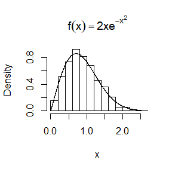

```r
knitr::opts_chunk$set(echo = TRUE)
n <- 1000
u <- rexp(n,rate=1)
x <- u^{1/2} #
hist(x, prob = TRUE, main = expression(f(x)==2*xe^{-x^2}))
y <- seq(0, 3, .001)
lines(y, 2*y*exp(1)^{-y^2})
```

when $\sigma=0.5$

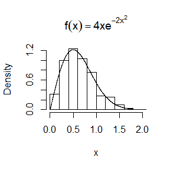

```r
knitr::opts_chunk$set(echo = TRUE)
n <- 1000
u <- rexp(n,rate=2)
x <- u^{1/2} #
hist(x, prob = TRUE, main = expression(f(x)==4*xe^{-2*x^2}))
y <- seq(0, 3, .001)
lines(y, 4*y*exp(1)^{-2*y^2})
```

when $\sigma=2$

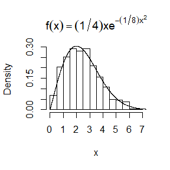

```r
knitr::opts_chunk$set(echo = TRUE)
n <- 1000
u <- rexp(n,rate=1/8)
x <- sqrt(u) #
hist(x, prob = TRUE, main = expression(f(x)==(1/4)*xe^{-(1/8)*x^2}))
y <- seq(0, 10, .001)
lines(y, (1/4)*y*exp(1)^{-(1/8)*y^2})
```

## the sencond question

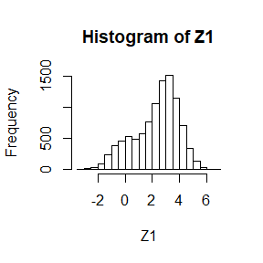

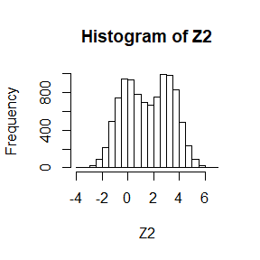

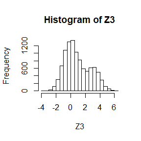

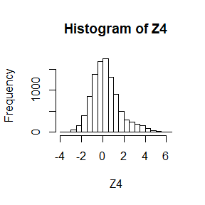

```r
n <- 1e4
X1 <- rnorm(n,mean = 0,sd=1)
X2 <- rnorm(n,mean = 3,sd=1)
r1 <- sample(c(0,1),n,replace=TRUE,prob = c(0.75,0.25))
r2 <- sample(c(0,1),n,replace=TRUE,prob = c(0.5,0.5))
r3 <- sample(c(0,1),n,replace=TRUE,prob = c(0.3,0.7))
r4 <- sample(c(0,1),n,replace=TRUE,prob = c(0.1,0.9))

Z1 <- r1*X1+(1-r1)*X2
Z2 <- r2*X1+(1-r2)*X2
Z3 <- r3*X1+(1-r3)*X2
Z4 <- r4*X1+(1-r4)*X2

hist(Z1);hist(Z2);hist(Z3);hist(Z4)
```

# Homework 3

## 5.1

Compute a Monte Carlo estimate of
$$\int_{0}^{π/3} sin t dt$$
and compare your estimate with the exact value of the integral.

### My solution

```r
set.seed(12345)
m<-1e4;t<-runif(m,min = 0,max = pi/3)
theta.hat<-mean(pi*sin(t)/3)#the Monte Carlo estimate
print(c(theta.hat,cos(0)-cos(pi/3)))
```

```
## [1] 0.5009124 0.5000000
```

From the result, we can get the MC estimate is 0.5009124, which is very close to the exact value of the integral.

## 5.10

Use Monte Carlo integration with antithetic variables to estimate
$$\int_{0}^{1} \frac{e^{-x}}{1+x^2} dx$$
and find the approximate reduction in variance as a percentage of the variance without variance reduction.

### My solution

```r
set.seed(1)
m<-1e4;x<-runif(m)
theta1<-mean(exp(-x)/(1+x^2))#the MC estimator of integration
u<-runif(m/2)
g<-.5*exp(-u)/(1+u^2)+.5*exp(-(1-u))/(1+(1-u)^2)
theta2<-mean(g)#the Antithetic variables estimator of integration
print(c(theta1,theta2))
```

```
## [1] 0.5252884 0.5247389
```

```r
MC1<-sd(exp(-x)/(1+x^2))/sqrt(m)#sd estimate of MC
MC2<-sd(g)/sqrt(m/2)#sd eatimate of Antithetic
cat("the variance of MC estimate=",MC1^2)
```

```
## the variance of MC estimate= 6.077993e-06
```

```r
cat("the variance of Antithetic estimate=",MC2^2)
```

```
## the variance of Antithetic estimate= 2.179475e-07
```

```r
cat("the approximate reduction in variance =",(MC1^2-MC2^2)/MC1^2)
```

```
## the approximate reduction in variance = 0.9641415
```

From the result,we can find the approximate reduction in variance is about 96.4%.

## 5.15

Obtain the stratified importance sampling estimate in Example 5.13 and compare it with the result of Example 5.10.

### My solution

If $x=-log(1-u*(1-e^{-1}))$ is belongs to $(a,b)$, we can get $x$ when $U \sim U(\frac{1-e^{-a}}{1-e^{-1}},\frac{1-e^{-b}}{1-e^{-1}})$

```r
##importance sampling estimate
M <- 50000
g <- function(x) {
  exp(-x - log(1+x^2)) * (x > 0) * (x < 1)
}
u <- runif(M)
x <- - log(1 - u * (1 - exp(-1)))
fg <- g(x) / (exp(-x) / (1 - exp(-1)))
theta0 <- mean(fg)
se0 <- sd(fg)#sd of importance sampling estimate
cat("se of importance sampling estimate=",se0)
```

```
## se of importance sampling estimate= 0.09693489
```

```r
cat("variance estimate of ISE=",se0^2/M)
```

```
## variance estimate of ISE= 1.879275e-07
```

```r
##stratified importance sampling estimate
theta.hat <- se <- numeric(5)
k<-5;m<-M/k

set.seed(524)
g1 <- function(x) {
  exp(-x - log(1+x^2)) * (x > 0) * (x < 1/5)
}
u1 <- runif(m,0,(1-exp(-1/5))/(1-exp(-1)))
x1 <- - log(1 - u1 * (1 - exp(-1)))#obtain x1 belongs to (0,1/5)
fg1 <- g1(x1) / (k*exp(-x1) / (1 - exp(-1)))
theta.hat[1] <- mean(fg1)
se[1] <- sd(fg1)

g2 <- function(x) {
  exp(-x - log(1+x^2)) * (x > 1/5) * (x < 2/5)
}
u2 <- runif(m,(1-exp(-1/5))/(1-exp(-1)),(1-exp(-2/5))/(1-exp(-1)))
x2 <- - log(1 - u2 * (1 - exp(-1)))#obtain x1 belongs to (1/5,2/5)
fg2 <- g(x2) / (k*exp(-x2) / (1 - exp(-1)))
theta.hat[2] <- mean(fg2)
se[2] <- sd(fg2)

g3 <- function(x) {
  exp(-x - log(1+x^2)) * (x > 2/5) * (x < 3/5)
}
u3 <- runif(m,(1-exp(-2/5))/(1-exp(-1)),(1-exp(-3/5))/(1-exp(-1)))
x3 <- - log(1 - u3 * (1 - exp(-1)))#obtain x1 belongs to (2/5,3/5)
fg3 <- g(x3) / (k*exp(-x3) / (1 - exp(-1)))
theta.hat[3] <- mean(fg3)
se[3] <- sd(fg3)

g4 <- function(x) {
  exp(-x - log(1+x^2)) * (x > 3/5) * (x < 4/5)
}
u4 <- runif(m,(1-exp(-3/5))/(1-exp(-1)),(1-exp(-4/5))/(1-exp(-1)))
x4 <- - log(1 - u4 * (1 - exp(-1)))#obtain x1 belongs to (3/5,4/5)
fg4 <- g(x4) / (k*exp(-x4) / (1 - exp(-1)))
theta.hat[4] <- mean(fg4)
se[4] <- sd(fg4)

g5 <- function(x) {
  exp(-x - log(1+x^2)) * (x > 4/5) * (x < 1)
}
u5 <- runif(m,(1-exp(-4/5))/(1-exp(-1)),1)
x5 <- - log(1 - u5 * (1 - exp(-1)))#obtain x1 belongs to (4/5,1)
fg5 <- g(x5) / (k*exp(-x5) / (1 - exp(-1)))
theta.hat[5] <- mean(fg5)
se[5] <- sd(fg5)

theta0-sum(theta.hat)#we can get the means is almast same between two methods
```

```
## [1] 0.02682569
```

```r
cat("variance estimate of SISE=",sum(se^2)/m)
```

```
## variance estimate of SISE= 7.399279e-09
```

```r
se0^2-sum(se^2)#the variance is much smaller
```

```
## [1] 0.009322381
```

```r
(se0^2-sum(se^2))/se0^2#Reduced percentage of variance
```

```
## [1] 0.9921254
```

In the result,we can find $\sigma^2 - k\sum_{j=1}^k \sigma_j^2=0.00932>0$,that is the variance of SISE is smaller than that of ISE. What’s more, the reduced percentage of variance is almost 99%.

# Homework 4

## 6.5

Suppose a 95% symmetric $t$-interval is applied to estimate a mean, but the sample data are non-normal. Then the probability that the confidence interval covers the mean is not necessarily equal to 0.95. Use a Monte Carlo experiment to estimate the coverage probability of the t-interval for random samples of $\chi ^2 (2)$ data with sample size $n$ = 20. Compare your $t$-interval results with the simulation results in Example 6.4. (The $t$-interval should be more robust to departures from normality than the interval for variance.)

### My solution

```r
#t-interval for mean
set.seed(223)
m<-1e4;n<-20;ECP<-numeric(2)
L<-U<-numeric(m)
for (i in 1:m) {
  x<-rchisq(n,2)
  y<-(x-mean(x))^2
  L[i]<-mean(x)-qt(.975, n-1)*sqrt(mean(y)/(n-1))
  U[i]<-mean(x)+qt(.975, n-1)*sqrt(mean(y)/(n-1))
}
c<-ifelse(L<2&2<U,1,0)#if the C.I. (L,U) covers the real mean,we make c equal to 1.
sum(c)/1e4#compute the CP
```

```
## [1] 0.9212
```

```r
#the interval for variance
#we can get the code from textbook
n <- 20
alpha <- .05
UCL <- replicate(1000, expr = {
x <- rchisq(n, df = 2)
(n-1) * var(x) / qchisq(alpha, df = n-1)
} )
sum(UCL > 4)
```

```
## [1] 799
```

```r
mean(UCL > 4)
```

```
## [1] 0.799
```

Compare two empirical coverage probability

```r
ECP[1]<-sum(c)/1e4
ECP[2]<-mean(UCL > 4)
data.frame(ECP, row.names = c('t-interval for mean','interval for variance'))
```

```
##                          ECP
## t-interval for mean   0.9212
## interval for variance 0.7990
```

From the result , when the data is departed from normality,we can get the $t$-interval for mean(92.12%) is more robust to than the interval for variance(79.9%).

## 6.6

Estimate the 0.025, 0.05, 0.95, and 0.975 quantiles of the skewness $\sqrt {b1}$ under normality by a Monte Carlo experiment. Compute the standard error of the estimates from (2.14) using the normal approximation for the density (with exact variance formula). Compare the estimated quantiles with the quantiles of the large sample approximation $\sqrt {b1} ≈ N(0, \frac 6n)$.

# Homework 5

## 6.7

Estimate the power of the skewness test of normality against symmetric Beta($\alpha , \alpha$) distributions and comment on the results. Are the results different for heavy-tailed symmetric alternatives such as $t(ν)$?

## solution

### against symmetric Beta($\alpha , \alpha$) distributions

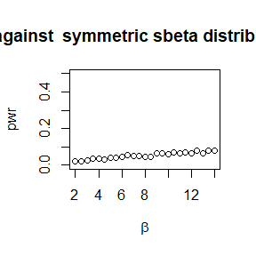

```r
sk <- function(x) {
  #computes the sample skewness coeff.
  xbar <- mean(x)
  m3 <- mean((x - xbar)^3)
  m2 <- mean((x - xbar)^2)
  return( m3 / m2^1.5 )
}

set.seed(013)
alpha <- .1
n <- 30
m <- 2500
beta <- seq(2, 14, .5)
N <- length(beta)
pwr <- numeric(N)
#critical value for the skewness test
cv <- qnorm(1-alpha/2, 0, sqrt(6*(n-2) / ((n+1)*(n+3))))

for (j in 1:N) { #for each beta
  a <- beta[j]
  sktests <- numeric(m)
  for (i in 1:m) { #for each replicate
    x <- rbeta(n,a,a)
    sktests[i] <- as.integer(abs(sk(x)) >= cv)
  }
  pwr[j] <- mean(sktests)
}

plot(beta, pwr, type = "b",
     xlab = bquote(beta),ylim = c(0,.5),
     main = 'against  symmetric sbeta distribution')
```

### agains heavy-tailed symmetric alternatives such as $t(ν)$

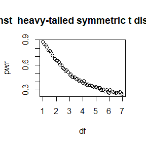

```r
set.seed(013)

df <- seq(1, 7, .1)
N <- length(df)
pwr <- numeric(N)
#critical value for the skewness test
cv <- qnorm(1-alpha/2, 0, sqrt(6*(n-2) / ((n+1)*(n+3))))

for (j in 1:N) { #for each df
  a <- df[j]
  sktests <- numeric(m)
  for (i in 1:m) { #for each replicate
    x <- rt(n,a)
    sktests[i] <- as.integer(abs(sk(x)) >= cv)
  }
  pwr[j] <- mean(sktests)
}

plot(df, pwr, type = "b",
     xlab = bquote(df),
     main = 'against  heavy-tailed symmetric t distribution')
```

From two plots, we can obviously find that the power(less than 0.1) of the skewness test of normality against symmetric Beta($\alpha , \alpha$) distributions is very small. On the contrary, the results is very different for heavy-tailed symmetric ditribution $t(ν)$,whose power can reach to 0.8 and is much larger than that of beta distribution.

## 6.A

Use Monte Carlo simulation to investigate whether the empirical Type I error rate of the t-test is approximately equal to the nominal significance level$\alpha$, when the sampled population is non-normal. The t-test is robust to mild departures from normality. Discuss the simulation results for the cases where the sampled population is (i) $\chi^2(1)$, (ii) Uniform(0,2), and (iii) Exponential(rate=1). In each case, test $H_0 : \mu = \mu_0$ vs $H_1 : \mu \neq \mu_0$, where $\mu _0$ is the mean of $\chi^2(1)$, Uniform(0,2), and Exponential(1), respectively.

## solution

We take $t(3)$ for example,which is non-normal and mild departures from normality. $ H_0 : = 0$ vs $H_1 : \mu \neq 0$,

```r
n <- 20;set.seed(013)
alpha <- .05
mu0 <- 0
m <- 10000 #number of replicates
p <- numeric(m) #storage for p-values
for (j in 1:m) {
x <- rt(n, 3)
ttest <- t.test(x, alternative = "two.sided", mu = mu0)
p[j] <- ttest$p.value
}
p.hat <- mean(p < alpha)
se.hat <- sqrt(p.hat * (1 - p.hat) / m)
print(c(p.hat, se.hat))
```

```
## [1] 0.042800000 0.002024059
```

We can find the empirical ty1 error is similar to nominal ty1 error (0.05).So we can conclude that the t-test is robust to mild departures from normality

### 6.A.1

when the sampled population is $\chi^2(1)$, whose mean equals 1

```r
n <- 20;set.seed(013)
alpha <- .05
mu0 <- 1
m <- 10000 #number of replicates
p <- numeric(m) #storage for p-values
for (j in 1:m) {
x <- rchisq(n, 1)
ttest <- t.test(x, alternative = "two.sided", mu = mu0)
p[j] <- ttest$p.value
}
p.hat <- mean(p < alpha)
print(p.hat)
```

```
## [1] 0.1048
```

We can find We can find the empirical ty1 error (0.1048) is far away from nominal ty1 error (0.05) when the sampled population is $\chi^2(1)$.

### 6.A.2

when the sampled population is uniform(0,2), whose mean equals 1

```r
n <- 20;set.seed(013)
alpha <- .05
mu0 <- 1
m <- 10000 #number of replicates
p <- numeric(m) #storage for p-values
for (j in 1:m) {
x <- runif(n,0, 2)
ttest <- t.test(x, alternative = "two.sided", mu = mu0)
p[j] <- ttest$p.value
}
p.hat <- mean(p < alpha)
print(p.hat)
```

```
## [1] 0.0499
```

We can find the empirical ty1 error (0.0499) is similar to nominal ty1 error (0.05) when the sampled population is uniform(0,2).

### 6.A.3

when the sampled population is $exp(1)$, whose mean equals 1

```r
n <- 20;set.seed(013)
alpha <- .05
mu0 <- 1
m <- 10000 #number of replicates
p <- numeric(m) #storage for p-values
for (j in 1:m) {
x <- rexp(n, 1)
ttest <- t.test(x, alternative = "two.sided", mu = mu0)
p[j] <- ttest$p.value
}
p.hat <- mean(p < alpha)
print(p.hat)
```

```
## [1] 0.0773
```

We can find the empirical ty1 error (0.0773) is far away from nominal ty1 error (0.05) when the sampled population is $exp(1)$

## 6.discussion

If we obtain the powers for two methods under a particular simulation setting with 10,000 experiments: say, 0.651 for one method and 0.676 for another method. Can we say the powers are different at 0.05 level? * What is the corresponding hypothesis test problem? * What test should we use? Z-test, two-sample t-test, paired-t test or McNemar test? * What information is needed to test your hypothesis?

## solution

*the null hypothesis $H_0$:the rate one = the rate two;$H_\alpha$:the rate one$\neq$the rate two

*two method can be saw as two binomial distribution of p equals 0.05. We can use Z-test of large sample.

```r
n<-10000
alpha<-0.05
xbar<-0.651;ybar<-0.676
pbar<-(xbar+ybar)/2 #the approximate probability
u<-(ybar-xbar)/sqrt((2*pbar*(1-pbar))/n)#Z-test value
cv <- qnorm(1-alpha/2, 0, 1)#the critical value
print(as.integer(abs(u) >= cv))
```

```
## [1] 1
```

```r
#the answer equals 1 means we reject the H0
```

From the result, we reject the null hypothesis, so we can’t say the powers are equal at 0.05 level. They are different in large probility.

# Homework 6

## 7.6

Efron and Tibshirani discuss the scor (bootstrap) test score data on 88 students who took examinations in five subjects [84, Table 7.1], [188, Table 1.2.1]. The first two tests (mechanics, vectors) were closed book and the last three tests (algebra, analysis, statistics) were open book. Each row of the data frame is a set of scores (xi1, . . . , xi5) for the ith student. Use a panel display to display the scatter plots for each pair of test scores. Compare the plot with the sample correlation matrix. Obtain bootstrap estimates of the standard errors for each of the following estimates: $\hat{\rho}_{12}=\hat{\rho}$(mec,vec),$\hat{\rho}_{34}=\hat{\rho}$(alg,ana), $\hat{\rho}_{35}=\hat{\rho}$(alg, sta), $\hat{\rho}_{45}=\hat{\rho}$(ana, sta).

## solution

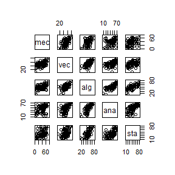

```r
library("bootstrap")
data(scor, package = "bootstrap")
pairs(scor,pch = 21)#the scatter plots
```

```r
cor(scor)#the sample correlation matrix
```

```
##           mec       vec       alg       ana       sta
## mec 1.0000000 0.5534052 0.5467511 0.4093920 0.3890993
## vec 0.5534052 1.0000000 0.6096447 0.4850813 0.4364487
## alg 0.5467511 0.6096447 1.0000000 0.7108059 0.6647357
## ana 0.4093920 0.4850813 0.7108059 1.0000000 0.6071743
## sta 0.3890993 0.4364487 0.6647357 0.6071743 1.0000000
```

From the the plot and the sample correlation matrix, we can find the more large the cor,the stronger linear relationship of the plot.

```r
#bootstrap estimates of the standard errors for each of the cor
#I don't know how to use loops to represent, so I wrote four functions.
library(boot)
set.seed(287)
#cor12
b.cor12 <- function(x,i){cor(scor[i,1],scor[i,2])}
obj<-boot(scor,b.cor12,R=999)
se12<-sd(obj$t)
#cor34
b.cor34 <- function(x,i){cor(scor[i,3],scor[i,4])}
obj<-boot(scor,b.cor34,R=999)
se34<-sd(obj$t)
#cor35
b.cor35 <- function(x,i){cor(scor[i,3],scor[i,5])}
obj<-boot(scor,b.cor35,R=999)
se35<-sd(obj$t)
#cor45
b.cor45 <- function(x,i){cor(scor[i,4],scor[i,5])}
obj<-boot(scor,b.cor45,R=999)
se45<-sd(obj$t)
round(c(SE12.boot=se12,SE34.boot=se34,SE35.boot=se35,SE45.boot=se45),4)
```

```
## SE12.boot SE34.boot SE35.boot SE45.boot
##    0.0801    0.0462    0.0602    0.0682
```

From the result,we can get the bootstrap estimates of the standard errors for $\hat{\rho}_{12}$ is 0.0801, for $\hat{\rho}_{34}$ is 0.0462, for $\hat{\rho}_{35}$ is 0.0602,for $\hat{\rho}_{45}$ is 0.0682.

## 7.B

(7.A Conduct a Monte Carlo study to estimate the coverage probabilities of the standard normal bootstrap confidence interval, the basic bootstrap confidence interval, and the percentile confidence interval. Sample from a normal population and check the empirical coverage rates for the sample mean. Find the proportion of times that the confidence intervals miss on the left, and the porportion of times that the confidence intervals miss on the right.)

7.B Repeat Project 7.A for the sample skewness statistic. Compare the coverage rates for normal populations (skewness 0) and $\chi^2(5)$ distributions (positive skewness)

## solution

```r
set.seed(014)
sk <- function(x) {
  #computes the sample skewness coeff.
  xbar <- mean(x)
  m3 <- mean((x - xbar)^3)
  m2 <- mean((x - xbar)^2)
  return( m3 / m2^1.5 )
}

#for normal population
theta<-0;b<-1;n<-2e1;m<-1e3;library(boot);set.seed(12345)
boot.sk <- function(x,i) sk(x[i])
ci.norm<-ci.basic<-ci.perc<-ci.bca<-matrix(NA,m,2)
for(i in 1:m){
  x <-rnorm(n)
  de <- boot(data=x,statistic=boot.sk, R = 999)
  ci <- boot.ci(de,type=c("norm","basic","perc"))
  ci.norm[i,]<-ci$norm[2:3]
  ci.basic[i,]<-ci$basic[4:5]
  ci.perc[i,]<-ci$percent[4:5]
}
CP1<-mean(ci.norm[,1]<=theta & ci.norm[,2]>=theta)
L1<-mean(ci.norm[,1]>=theta);R1<-mean( ci.norm[,2]<=theta)
CP2<-mean(ci.basic[,1]<=theta & ci.basic[,2]>=theta)
L2<-mean(ci.basic[,1]>=theta);R2<-mean( ci.basic[,2]<=theta)
CP3<-mean(ci.perc[,1]<=theta & ci.perc[,2]>=theta)
L3<-mean(ci.perc[,1]>=theta);R3<-mean( ci.perc[,2]<=theta)
CP<-c(CP1,CP2,CP3);L<-c(L1,L2,L3);R<-c(R1,R2,R3)
data.frame("CP"=CP,"Miss on the left"=L,"Miss on the right" =R,
           row.names =c("norm","basic","perc"))
```

```
##          CP Miss.on.the.left Miss.on.the.right
## norm  0.892            0.052             0.056
## basic 0.884            0.052             0.064
## perc  0.973            0.014             0.013
```

```r
#for $\chi^2(5)$
set.seed(013)
theta<-4/sqrt(10)#the real sk of \chisq(5)
b<-1;n<-20;m<-1e3;library(boot);set.seed(12345)
boot.sk <- function(x,i) sk(x[i])
ci.norm<-ci.basic<-ci.perc<-ci.bca<-matrix(NA,m,2)
for(i in 1:m){
  x <-rchisq(n,5)
  de <- boot(data=x,statistic=boot.sk, R = 999)
  ci <- boot.ci(de,type=c("norm","basic","perc"))
  ci.norm[i,]<-ci$norm[2:3]
  ci.basic[i,]<-ci$basic[4:5]
  ci.perc[i,]<-ci$percent[4:5]
}
CP1<-mean(ci.norm[,1]<=theta & ci.norm[,2]>=theta)
L1<-mean(ci.norm[,1]>=theta);R1<-mean( ci.norm[,2]<=theta)
CP2<-mean(ci.basic[,1]<=theta & ci.basic[,2]>=theta)
L1<-mean(ci.basic[,1]>=theta);R1<-mean( ci.basic[,2]<=theta)
CP3<-mean(ci.perc[,1]<=theta & ci.perc[,2]>=theta)
L1<-mean(ci.perc[,1]>=theta);R1<-mean( ci.perc[,2]<=theta)
CP<-c(CP1,CP2,CP3);L<-c(L1,L2,L3);R<-c(R1,R2,R3)
data.frame("CP"=CP,"Miss on the left"=L,"Miss on the right" =R,
           row.names =c("norm","basic","perc"))
```

```
##          CP Miss.on.the.left Miss.on.the.right
## norm  0.742            0.000             0.275
## basic 0.722            0.052             0.064
## perc  0.725            0.014             0.013
```

The first line is the cp of normal,basic and percentile.The second lines reprents the proportion of times that the confidence intervals miss on the left. And the third line isthe proportion of times that the confidence intervals miss on the right.

We can obviously find the CP of the sample skewness statistic for normal populations is better than that for $\chi^2(5)$ distributions.

# Homework 7

## Exercise 11.4

Find the intersection points $A(k)$ in $(0,\sqrt{k})$ of the curves
$$S_{k-1}(a)=P(t(k-1)>\sqrt{\frac{a^2(k-1)}{k-a^2}})$$
and
$$S_{k}(a)=P(t(k)>\sqrt{\frac{a^2k}{k+1-a^2}})$$
for $k =4: 25, 100, 500, 1000$, where $t(k)$ is a Student $t$ random variable with $k$ degrees of freedom.

## Answer

Firstly, we define a function S with parameters $k$ and $a$ to generate the curve $S_k(a)-S_{k-1}(a)$. If we can compute the intersection points of the curves $S_k(a)$ and $S_{k-1}(a)$ by computing the root of function $S_k(a)-S_{k-1}(a)$.

I use bisection method to solve this problem.

```r
set.seed(1)
eps <- .Machine$double.eps^0.25#criterion to judge whether function is near to 0
k <- c(4:25,100,500,1000)#k mentioned in the question

S <- function(k,a){
  return((1-pt(sqrt((a^2*k)/(k+1-a^2)),df = k))-(1-pt(sqrt((a^2*(k-1))/(k-a^2)),df=k-1)))
}#S_k(a)-S_{k-1}(a)


Root <- function(k1){
a <- seq(0.1, sqrt(k1)-0.1,length = 3)
y <- c(S(k1,a[1]), S(k1,a[2]), S(k1,a[3]))
while(abs(y[2]) > eps) {
  if (y[1] * y[2] < 0) {
    a[3] <- a[2]
    y[3] <- y[2]
  } else {
    a[1] <- a[2]
    y[1] <- y[2]
  }
  a[2] <- (a[1] + a[3]) / 2
  y[2] <- S(k1,a[2])
}
result <-list(k1,a[2],y[2])
return(result)
}

for(i in k){#print the output of each k
  cat('k:',Root(i)[[1]],'root:',Root(i)[[2]],'value of function:',Root(i)[[3]],'\n')

}
```

```
## k: 4 root: 1.492188 value of function: 2.19293e-06
## k: 5 root: 1.53161 value of function: -2.600727e-05
## k: 6 root: 1.576228 value of function: 0.000107711
## k: 7 root: 1.59038 value of function: 3.14324e-05
## k: 8 root: 1.57849 value of function: -8.553791e-05
## k: 9 root: 1.5875 value of function: -7.580885e-05
## k: 10 root: 1.581139 value of function: -9.644197e-05
## k: 11 root: 1.658312 value of function: 3.993887e-05
## k: 12 root: 1.732051 value of function: 0.0001166009
## k: 13 root: 1.589929 value of function: -6.878761e-05
## k: 14 root: 1.649475 value of function: -4.503052e-06
## k: 15 root: 1.70693 value of function: 3.769164e-05
## k: 16 root: 1.525 value of function: -0.000104609
## k: 17 root: 1.571165 value of function: -6.213979e-05
## k: 18 root: 1.61599 value of function: -3.041938e-05
## k: 19 root: 1.659587 value of function: -6.8282e-06
## k: 20 root: 2.236068 value of function: 0.0001210204
## k: 21 root: 2.291288 value of function: 0.0001079948
## k: 22 root: 2.345208 value of function: 9.578466e-05
## k: 23 root: 2.397916 value of function: 8.454769e-05
## k: 24 root: 2.44949 value of function: 7.434282e-05
## k: 25 root: 2.5 value of function: 6.516662e-05
## k: 100 root: 5 value of function: 1.068744e-09
## k: 500 root: 11.18034 value of function: 0
## k: 1000 root: 15.81139 value of function: 0
```

Next, I plot two curves to show in two cases, the intersection points computed by the algorithm is the very zero point of the difference of two functions.

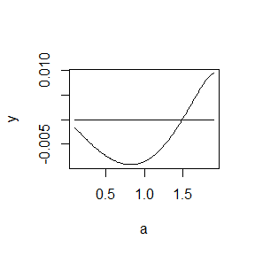

```r
k <- 4
a <- seq(0.1,sqrt(k)-0.1,0.01)
y0 <- numeric(length(a))
y <- (1-pt(sqrt((a^2*k)/(k+1-a^2)),df = k))-(1-pt(sqrt((a^2*(k-1))/(k-a^2)),df=k-1))
plot(a,y,'l')
lines(a,y0)
```

```r
cat('The root of curves when k = ',k,'is',Root(k)[[2]],'\n')
```

```
## The root of curves when k =  4 is 1.492188
```

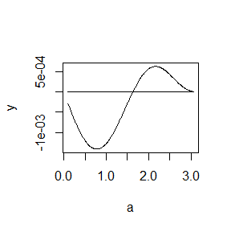

```r
k <- 10
a <- seq(0.1,sqrt(k)-0.1,0.01)
y0 <- numeric(length(a))
y <- (1-pt(sqrt((a^2*k)/(k+1-a^2)),df = k))-(1-pt(sqrt((a^2*(k-1))/(k-a^2)),df=k-1))
plot(a,y,'l')
lines(a,y0)
```

```r
cat('The root of curves when k = ',k,'is',Root(k)[[2]],'\n')
```

```
## The root of curves when k =  10 is 1.581139
```

As the figures present, the intersection of the function value and zero is the numble computed exactly.

# Homework 8

## 7.8

Refer to Exercise 7.7. Obtain the jackknife estimates of bias and standard error of $\hat{\theta}$.

## solution of 7.8

```r
data(scor, package = "bootstrap")
n <- nrow(scor)
#jackknife
cov1<-cov(scor)
ev1<-eigen(cov1)
lambda1<-sort(ev1$values)[5]
theta.hat<-lambda1/sum(ev1$values)
theta.jack <- numeric(n)
for (i in 1:n){
  cov2<-cov(scor[-i,])
  ev2<-eigen(cov2)
  lambda2<-sort(ev2$values)[5]
  theta.jack[i]<-lambda2/sum(ev2$values)
}
bias_jack <- (n-1)*(mean(theta.jack) - theta.hat)
se_jack<-sqrt((n-1)*mean((theta.jack - mean(theta.jack))^2))
data.frame("bias_jack"=bias_jack,"se_jack"=se_jack)
```

```
##     bias_jack    se_jack
## 1 0.001069139 0.04955231
```

From the results, we can get the jackknife estimates of bias equals 0.00106913 andthe jackknife estimates of standard error equals 0.04955231.

## 7.10

In Example 7.18, leave-one-out (n-fold) cross validation was used to select the best fitting model. Repeat the analysis replacing the Log-Log model with a cubic polynomial model. Which of the four models is selected by the cross validation procedure? Which model is selected according to maximum adjusted $R^2$?

## solution of 7.10

```r
library(DAAG); attach(ironslag)
```

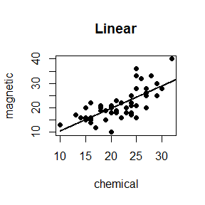

```r
a <- seq(10, 40, .1) #sequence for plotting fits
L1 <- lm(magnetic ~ chemical)
plot(chemical, magnetic, main="Linear", pch=16)
yhat1 <- L1$coef[1] + L1$coef[2] * a
lines(a, yhat1, lwd=2)
```

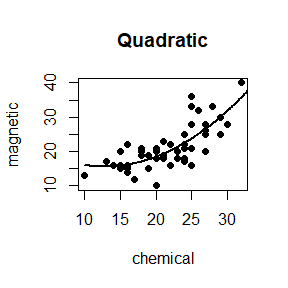

```r
L2 <- lm(magnetic ~ chemical + I(chemical^2))
plot(chemical, magnetic, main="Quadratic", pch=16)
yhat2 <- L2$coef[1] + L2$coef[2] * a + L2$coef[3] * a^2
lines(a, yhat2, lwd=2)
```

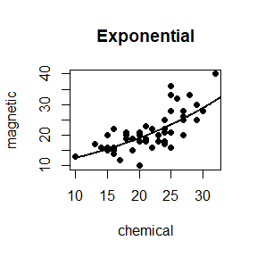

```r
L3 <- lm(log(magnetic) ~ chemical)
plot(chemical, magnetic, main="Exponential", pch=16)
logyhat3 <- L3$coef[1] + L3$coef[2] * a
yhat3 <- exp(logyhat3)
lines(a, yhat3, lwd=2)
```

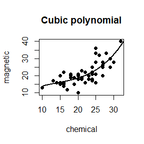

```r
L4 <- lm(magnetic ~ chemical + I(chemical^2) + I(chemical^3))#cubic polynimial
plot(chemical, magnetic, main="Cubic polynomial", pch=16)
yhat4 <- L4$coef[1] + L4$coef[2] * a + L4$coef[3] * a^2 + L4$coef[4] * a^3
lines(a, yhat4, lwd=2)
```

```r
n <- length(magnetic) #in DAAG ironslag
e1 <- e2 <- e3 <- e4 <- numeric(n)
# for n-fold cross validation
# fit models on leave-one-out samples
for (k in 1:n) {
  y <- magnetic[-k]
  x <- chemical[-k]
  J1 <- lm(y ~ x)
  yhat1 <- J1$coef[1] + J1$coef[2] * chemical[k]
  e1[k] <- magnetic[k] - yhat1

  J2 <- lm(y ~ x + I(x^2))
  yhat2 <- J2$coef[1] + J2$coef[2] * chemical[k] +
    J2$coef[3] * chemical[k]^2
  e2[k] <- magnetic[k] - yhat2

  J3 <- lm(log(y) ~ x)
  logyhat3 <- J3$coef[1] + J3$coef[2] * chemical[k]
  yhat3 <- exp(logyhat3)
  e3[k] <- magnetic[k] - yhat3

  J4 <- lm(y ~ x + I(x^2) +I(x^3))#cubic polynomial
  yhat4 <- J4$coef[1] + J4$coef[2] * chemical[k] +
    J4$coef[3] * chemical[k]^2 + J4$coef[4] * chemical[k]^3
  e4[k] <- magnetic[k] - yhat4
}
data.frame("MSE1"=mean(e1^2),"MSE2"=mean(e2^2),"MSE3"=mean(e3^2),"MSE4"=mean(e4^2),row.names = "MSE from the n-fold cross validation.")
```

```
##                                           MSE1     MSE2     MSE3     MSE4
## MSE from the n-fold cross validation. 19.55644 17.85248 18.44188 18.17756
```

```r
data.frame("R^2 of L2"=summary(J2)$adj.r.squared,"R^2 of L4"=summary(J4)$adj.r.squared,row.names = "maximum adjusted R^2")
```

```
##                      R.2.of.L2 R.2.of.L4
## maximum adjusted R^2 0.5909726 0.5937184
```

I replacing the Log-Log model with a cubic polynomial model.The L4 and J4 are both a cubic polynomial model.

From the results, the MSE of J4 equals 18.17756,which is also larger than the MSE of J2.Thus, we still choose the Quadratic model from MSE.

From the maximum adjusted R^2, we can find the maximum adjusted R^2 of J2 equals 0.59097 ,which is small than maximum adjusted R^2 of J4(0.59373).In this case,we will choose the cubic polynomial.

# Homework 9

## 8.3

The Count 5 test for equal variances in Section 6.4 is based on the maximum number of extreme points. Example 6.15 shows that the Count 5 criterion is not applicable for unequal sample sizes. Implement a permutation test for equal variance based on the maximum number of extreme points that applies when sample sizes are not necessarily equal.

## Solution

```r
x <- rnorm(20, 0, sd = 1)
y <- rnorm(30, 0, sd = 2)
z <- c(x, y)
R <- 999;K <-1:50;n<-length(x);set.seed(0374)
reps <- numeric(R)
#define the count five test function
count5test <- function(x, y) {
  X <- x - mean(x)
  Y <- y - mean(y)
  outx <- sum(X > max(Y)) + sum(X < min(Y))
  outy <- sum(Y > max(X)) + sum(Y < min(X)) # return 1 (reject) or 0 (do not reject H0)
  #return(as.integer(max(c(outx, outy)) > 5))
  return(max(c(outx, outy)))
  }
t0 <- count5test(x,y)
# Implement a permutation test
for (i in 1:R){
  k <- sample(K, size = n, replace = FALSE)
  x1 <- z[k]
  y1 <- z[-k]
  reps[i] <- count5test(x1,y1)
}
p <- mean(abs(c(t0, reps)) >= abs(t0))
print(p)
```

```
## [1] 0.03
```

As code above, I implement a permutation test for equal variance based on the maximum number of extreme points that applies when sample sizes are not necessarily equal. the p-value is smaller than 0.05, Thus, we can’t say the two samples have same variance, which in line with the actual situation.

## 8.Discussion

Power conparison (distance correlation test vs ball covariance test)

Model 1:$Y=\frac X 4 + e$

Model 2:$Y=\frac X 4 * e$

$x \sim N(0_2,I_2),~e\sim N(0_2,I_2)$,~X and e are independent

## Solution

```r
#Empirical distance covariance
dCov <- function(x, y) {
  x <- as.matrix(x); y <- as.matrix(y)
  n <- nrow(x); m <- nrow(y)
  if (n != m || n < 2) stop("Sample sizes must agree")
  if (! (all(is.finite(c(x, y)))))
    stop("Data contains missing or infinite values")
  Akl <- function(x) {
    d <- as.matrix(dist(x))
    m <- rowMeans(d); M <- mean(d)
    a <- sweep(d, 1, m); b <- sweep(a, 2, m)
    b + M
  }
  A <- Akl(x); B <- Akl(y)
  sqrt(mean(A * B))
}
ndCov2 <- function(z, ix, dims) {
  #dims contains dimensions of x and y
  p <- dims[1]
  q <- dims[2]
  d <- p + q
  x <- z[ , 1:p] #leave x as is
  y <- z[ix, -(1:p)] #permute rows of y
  return(nrow(z) * dCov(x, y)^2)
}

library("boot")
#the function to generate random number of Model 1
rd1 <- function(n){
  x <- mvrnorm(n,c(0,0),matrix(c(1,0,0,1),2))
  e <- mvrnorm(n,c(0,0),matrix(c(1,0,0,1),2))
  y <- 0.25*x+e
  z <- data.frame(x,y)
  return(z)
}
#the function to generate random number of Model 2
rd2 <- function(n){
  x <- mvrnorm(n,c(0,0),matrix(c(1,0,0,1),2))
  e <- mvrnorm(n,c(0,0),matrix(c(1,0,0,1),2))
  y <- 0.25*x*e
  z <- data.frame(x,y)
  return(z)
}
#obtain p-value of disrance correlation
p.dcf <- function(z){
  boot.obj <- boot(data = z, statistic = ndCov2, R = 100,
                 sim = "permutation", dims = c(2, 2))
  tb <- c(boot.obj$t0, boot.obj$t)
  p.cov <- mean(tb>=tb[1])
  return(p.cov)
}
#obtain p-value of ball covariance test
p.bcf <- function(z){
  p.bc <- bcov.test(z[,1:2],z[,3:4],R=100,seed = i*123)$p.value
  return(p.bc)
}

library(MASS)
library(Ball)
m <- 50;p.values <- matrix(NA,m,3)
for (i in 1:m) {
  p.values[i,1] <-p.dcf(rd1(10))
  p.values[i,2] <-p.dcf(rd1(50))
  p.values[i,3] <-p.dcf(rd1(100))
}
pow1_dc <- colMeans(p.values<0.05)#power of DC in model 1
for (i in 1:m) {
  p.values[i,1] <-p.bcf(rd1(10))
  p.values[i,2] <-p.bcf(rd1(50))
  p.values[i,3] <-p.bcf(rd1(100))
}
pow1_bc <- colMeans(p.values<0.05)#power of BC in model 1
for (i in 1:m) {
  p.values[i,1] <-p.dcf(rd2(10))
  p.values[i,2] <-p.dcf(rd2(50))
  p.values[i,3] <-p.dcf(rd2(100))
}
pow2_dc <- colMeans(p.values<0.05)#power of DC in model 2
for (i in 1:m) {
  p.values[i,1] <-p.bcf(rd2(10))
  p.values[i,2] <-p.bcf(rd2(50))
  p.values[i,3] <-p.bcf(rd2(100))
}
pow2_bc <- colMeans(p.values<0.05)#power of BC in model 2
N <- c(10,50,100)
data.frame(N,pow1_dc,pow1_bc,pow2_dc,pow2_bc)
```

```
##     N pow1_dc pow1_bc pow2_dc pow2_bc
## 1  10    0.10    0.08    0.20    0.26
## 2  50    0.52    0.24    0.50    0.94
## 3 100    0.74    0.36    0.74    1.00
```

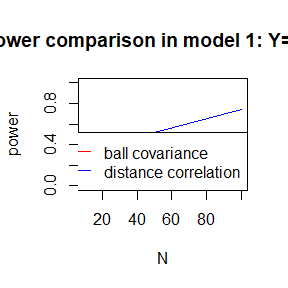

```r
plot(N,pow1_dc,type = "l",col = "blue",ylab = "power",ylim = c(0,1),main = "power comparison in model 1: Y=X/4+e")
lines(N,pow1_bc,col = "red")
legend("bottomright",legend=c("ball covariance","distance correlation"),
       col=c("red","blue"),lty=1,lwd=1)
```

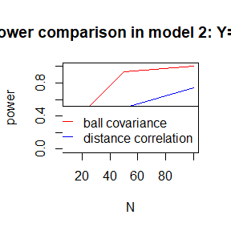

```r
plot(N,pow2_dc,type = "l",col = "blue",ylab = "power",ylim = c(0,1),main = "power comparison in model 2: Y=X/4*e")
lines(N,pow2_bc,col = "red")
legend("bottomright",legend=c("ball covariance","distance correlation"),
       col=c("red","blue"),lty=1,lwd=1)
```

As the code above, for each model, I choose three kind of sample size (10、50、100) to compare the power of each method.

In the model $y=\frac x4+e$, we can find the power of distance correlation is always larger than that of ball covariance. On the countrary, in the model $y=\frac x4 *e$, the method ball covariance peform better than distance correlation.

# Homework 10

## 9.4

Implement a random walk Metropolis sampler for generating the standard Laplace distribution (see Exercise 3.2). For the increment, simulate from a normal distribution. Compare the chains generated when different variances are used for the proposal distribution. Also, compute the acceptance rates of each chain

## solution

The standard Laplace distribution has density $f(x) = \frac1 2e^{−|x|}$

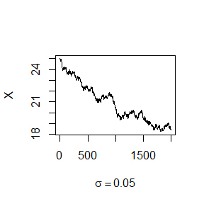

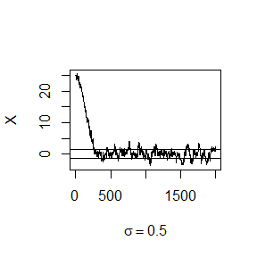

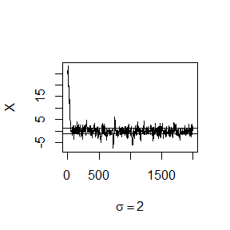

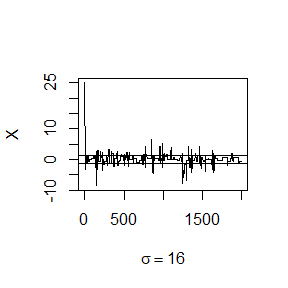

```r
dt<- function(x) 0.5*exp(1)^(-abs(x))

rw.Metropolis <- function( sigma, x0, N) {
  x <- numeric(N)
  x[1] <- x0
  u <- runif(N)
  k <- 0
  for (i in 2:N) {
    y <- rnorm(1, x[i-1], sigma)
    if (u[i] <= (dt(y) / dt(x[i-1])))
      x[i] <- y else {
        x[i] <- x[i-1]
        k <- k + 1
      }
  }
  return(list(x=x, k=k))
}

N <- 2000
sigma <- c(.05, .5, 2, 16)
x0 <- 25
rw1 <- rw.Metropolis( sigma[1], x0, N)
rw2 <- rw.Metropolis( sigma[2], x0, N)
rw3 <- rw.Metropolis( sigma[3], x0, N)
rw4 <- rw.Metropolis( sigma[4], x0, N)


q1 <- log10(1-2*abs(0.025-0.5))#the 0.025 quantile of Laplace distribution
q2 <- -log10(1-2*abs(0.975-0.5))#the 0.975 quantile of Laplace distribution
qs <- c(q1,q2)
rw <- cbind(rw1$x, rw2$x, rw3$x,  rw4$x)
for (j in 1:4) {
  plot(rw[,j], type="l",
       xlab=bquote(sigma == .(round(sigma[j],3))),
       ylab="X", ylim=range(rw[,j]))
  abline(h=qs)
}
```

```r
ac <- c(rw1$k, rw2$k, rw3$k, rw4$k)
ac.rate <- (N-ac)/N
rbind(sigma, ac.rate)#the acceptance rates of each chain
```

```
##         [,1]  [,2]  [,3]    [,4]
## sigma   0.05 0.500 2.000 16.0000
## ac.rate 0.98 0.834 0.539  0.0945
```

We can find the third one ($\sigma = 2)$ performs better than others. And the acceptance rate is about 0.5.

# Homework 11

## 11.1

The natural logarithm and exponential functions are inverses of each other, so that mathematically log(exp x) = exp(log x) = x. Show by example that this property does not hold exactly in computer arithmetic. Does the identity hold with near equality? (See all.equal.)

```r
log(exp(5))
```

```
## [1] 5
```

```r
exp(log(5))
```

```
## [1] 5
```

```r
log(exp(5))-exp(log(5))
```

```
## [1] 8.881784e-16
```

```r
isTRUE(all.equal(log(exp(5)),exp(log(5))))
```

```
## [1] TRUE
```

We can find the difference of $log(e^5)-e^{log(5)}$ equls $8.88*10^{-16}$, which is not equal to 0. So this property does not hold exactly in computer arithmetic.

But the difference is samll than the tolerance(=1.490116e-08). So the identity hold with near equality (in all.equal)

## 11.5

```r
ks  <- c(4:25,100)
n <- length(ks)
A1 <- A2 <- numeric(n)
cf <- function(k,a){
  return(sqrt(a^2*k/(k+1-a^2)))
}

f1 <- function(u){
  (1+u^2/(k-1))^(-k/2)
}
f2 <- function(u){which
  (1+u^2/k)^(-(k+1)/2)
}
g1 <- function(a){
  2*gamma(k/2)/(sqrt(pi*(k-1))*gamma((k-1)/2))*integrate(f1,0,cf(k-1,a))$value-2*gamma((k+1)/2)/(sqrt(pi*k)*gamma(k/2))*integrate(f2,0,cf(k,a))$value
}#soluton of question 11.5
g2 <- function(a){
  1-pt(cf(k-1,a),k-1)-1+pt(cf(k,a),k)
} #solution of question 11.4

for (i in 1:n) {
  k <- ks[i]
  A1[i] <- uniroot(g1,c(0.05,sqrt(k)/2+1))$root
  A2[i] <- uniroot(g2,c(0.01,sqrt(k)/2+1))$root
}
A1
```

```
##  [1] 1.492104 1.533559 1.562745 1.584428 1.601182 1.614529 1.625383 1.634409
##  [9] 1.642028 1.648537 1.654188 1.659121 1.663434 1.667304 1.670732 1.673816
## [17] 1.676604 1.679153 1.681483 1.683594 1.685546 1.687356 1.720599
```

```r
A2
```

```
##  [1] 1.492103 1.533576 1.562721 1.584427 1.601166 1.614524 1.625385 1.634415
##  [9] 1.642027 1.648536 1.654175 1.659097 1.663408 1.667301 1.670724 1.673819
## [17] 1.676589 1.679154 1.681470 1.683610 1.685548 1.687347 1.720610
```

## A-B-O blood type problem

```r
library(rootSolve)
set.seed(013)
N <- 2e2
nA <- 28
nB <- 24
nO <- 41
nAB<-70
E <- numeric(N)
L <- c(.1,.1)#setting Initial value
tol <- .Machine$double.eps^0.5
L.old <- L+1
for(j in 1:N){
  E[j]<-2*L[1]*nA*log(L[1])/(2-L[1]-2*L[2])
  +2*L[2]*nB*log(L[2])/(2-L[2]-2*L[1])
  +2*nO*log(1-L[1]-L[2])
  +nA*(2-2*L[1]-2*L[2])*log(2*L[1]*(1-L[1]-L[2]))/(2-L[1]-2*L[2])
  +nB*(2-2*L[1]-2*L[2])*log(2*L[2]*(1-L[1]-L[2]))/(2-L[2]-2*L[1])
  +nAB*log(2*L[1]*L[2])#E-step expression
  model<-function(x){
    #use R.function multiroot to  solve the max for M-step
    F1<-2*L[1]*nA/((2-L[1]-2*L[2])*x[1])-2*nO/(1-x[1]-x[2])+nA*(2-2*L[1]-2*L[2])*(1-2*x[1]-x[2])/((2-L[1]-2*L[2])*x[1]*(1-x[1]-x[2]))-nB*(2-2*L[1]-2*L[2])/((2-L[2]-2*L[1])*(1-x[1]-x[2]))+nAB/x[1]
    F2<-2*L[2]*nB/((2-L[2]-2*L[1])*x[2])-2*nO/(1-x[1]-x[2])-nA*(2-2*L[1]-2*L[2])/((2-L[1]-2*L[2])*(1-x[1]-x[2]))+nB*(2-2*L[1]-2*L[2])*(1-2*x[2]-x[1])/((2-L[2]-2*L[1])*x[2]*(1-x[1]-x[2]))+nAB/x[2]
    c(F1=F1,F2=F2)
  }
  tt<-multiroot(f=model,star=c(.1,.1))
  L<-tt$root
  if (sum(abs(L-L.old)/L.old)<tol) break
  L.old<-L
}
data.frame("p-hat" = L.old[1],"q-hat" = L.old[2])
```

```
##       p.hat     q.hat
## 1 0.3273442 0.3104267
```

# Homework 12

## Q3

Use both for loops and lapply() to fit linear models to the mtcars using the formulas stored in this list:  
formulas <- list( mpg ~ disp, mpg ~ I(1 / disp), mpg ~ disp + wt, mpg ~ I(1 / disp) + wt )

```r
data("mtcars")
attach(mtcars)
formulas <- list(
  mpg ~ disp,
  mpg ~ I(1 / disp),
  mpg ~ disp + wt,
  mpg ~ I(1 / disp) + wt
)
#for loop
out_loop_1 <- vector("list", length(formulas))
for (i in seq_along(formulas)) {
  out_loop_1[[i]] <- lm(formulas[[i]])
}
out_loop_1
```

```
## [[1]]
##
## Call:
## lm(formula = formulas[[i]])
##
## Coefficients:
## (Intercept)         disp
##    29.59985     -0.04122
##
##
## [[2]]
##
## Call:
## lm(formula = formulas[[i]])
##
## Coefficients:
## (Intercept)    I(1/disp)
##       10.75      1557.67
##
##
## [[3]]
##
## Call:
## lm(formula = formulas[[i]])
##
## Coefficients:
## (Intercept)         disp           wt
##    34.96055     -0.01772     -3.35083
##
##
## [[4]]
##
## Call:
## lm(formula = formulas[[i]])
##
## Coefficients:
## (Intercept)    I(1/disp)           wt
##      19.024     1142.560       -1.798
```

```r
#lapply
out_lap_1 <- lapply(formulas, lm)
out_lap_1
```

```
## [[1]]
##
## Call:
## FUN(formula = X[[i]])
##
## Coefficients:
## (Intercept)         disp
##    29.59985     -0.04122
##
##
## [[2]]
##
## Call:
## FUN(formula = X[[i]])
##
## Coefficients:
## (Intercept)    I(1/disp)
##       10.75      1557.67
##
##
## [[3]]
##
## Call:
## FUN(formula = X[[i]])
##
## Coefficients:
## (Intercept)         disp           wt
##    34.96055     -0.01772     -3.35083
##
##
## [[4]]
##
## Call:
## FUN(formula = X[[i]])
##
## Coefficients:
## (Intercept)    I(1/disp)           wt
##      19.024     1142.560       -1.798
```

## Q4

Fit the model mpg ~ disp to each of the bootstrap replicates of mtcars in the list below by using a for loop and lapply(). Can you do it without an anonymous function? bootstraps <- lapply(1:10, function(i) { rows <- sample(1:nrow(mtcars), rep = TRUE) mtcars[rows, ] })

```r
bootstraps <- lapply(1:10, function(i) {
  rows <- sample(1:nrow(mtcars), rep = TRUE)
  mtcars[rows, ]
})
#for loop
out_loop_2 <- vector("list", length(bootstraps))
for (i in seq_along(bootstraps)) {
  f <- function(x){lm(mpg~disp, data=x)}
  out_loop_2[[i]] <- f(bootstraps[[i]])
}
out_loop_2
```

```
## [[1]]
##
## Call:
## lm(formula = mpg ~ disp, data = x)
##
## Coefficients:
## (Intercept)         disp
##     27.7921      -0.0354
##
##
## [[2]]
##
## Call:
## lm(formula = mpg ~ disp, data = x)
##
## Coefficients:
## (Intercept)         disp
##     27.2344      -0.0354
##
##
## [[3]]
##
## Call:
## lm(formula = mpg ~ disp, data = x)
##
## Coefficients:
## (Intercept)         disp
##    30.32630     -0.04227
##
##
## [[4]]
##
## Call:
## lm(formula = mpg ~ disp, data = x)
##
## Coefficients:
## (Intercept)         disp
##    28.66946     -0.03525
##
##
```

[output cut: 43 more lines]

```
## lm(formula = mpg ~ disp, data = x)
##
## Coefficients:
## (Intercept)         disp
##    28.05962     -0.03704
##
##
## [[10]]
##
## Call:
## lm(formula = mpg ~ disp, data = x)
##
## Coefficients:
## (Intercept)         disp
##    28.69104     -0.03534
```

```r
#lapply
out_lap_2 <- lapply(bootstraps, lm, formula = mpg ~ disp)
out_lap_2
```

```
## [[1]]
##
## Call:
## FUN(formula = ..1, data = X[[i]])
##
## Coefficients:
## (Intercept)         disp
##     27.7921      -0.0354
##
##
## [[2]]
##
## Call:
## FUN(formula = ..1, data = X[[i]])
##
## Coefficients:
## (Intercept)         disp
##     27.2344      -0.0354
##
##
## [[3]]
##
## Call:
## FUN(formula = ..1, data = X[[i]])
##
## Coefficients:
## (Intercept)         disp
##    30.32630     -0.04227
##
##
## [[4]]
##
## Call:
## FUN(formula = ..1, data = X[[i]])
##
## Coefficients:
## (Intercept)         disp
##    28.66946     -0.03525
##
##
```

[output cut: 43 more lines]

```
## FUN(formula = ..1, data = X[[i]])
##
## Coefficients:
## (Intercept)         disp
##    28.05962     -0.03704
##
##
## [[10]]
##
## Call:
## FUN(formula = ..1, data = X[[i]])
##
## Coefficients:
## (Intercept)         disp
##    28.69104     -0.03534
```

## Q5

For each model in the previous two exercises, extract R2 using the function below. rsq <- function(mod) summary(mod)$r.squared

```r
rsq <- function(mod) summary(mod)$r.squared
#for exercises 1
unlist(lapply(out_loop_1, rsq))
```

```
## [1] 0.7183433 0.8596865 0.7809306 0.8838038
```

```r
unlist(lapply(out_lap_1, rsq))
```

```
## [1] 0.7183433 0.8596865 0.7809306 0.8838038
```

```r
#for exercise 2
unlist(lapply(out_loop_2, rsq))
```

```
##  [1] 0.7466049 0.6552023 0.7588687 0.6643541 0.6227079 0.7468863 0.6630090
##  [8] 0.7530685 0.8654666 0.5655179
```

```r
unlist(lapply(out_lap_2, rsq))
```

```
##  [1] 0.7466049 0.6552023 0.7588687 0.6643541 0.6227079 0.7468863 0.6630090
##  [8] 0.7530685 0.8654666 0.5655179
```

## 3

The following code simulates the performance of a t-test for non-normal data. Use sapply() and an anonymous function to extract the p-value from every trial. trials <- replicate( 100, t.test(rpois(10, 10), rpois(7, 10)), simplify = FALSE ) Extra challenge: get rid of the anonymous function by using [[ directly.

```r
trials <- replicate(
  100,
  t.test(rpois(10, 10), rpois(7, 10)),
  simplify = FALSE
)
sapply(trials, function(x) x$p.value)
```

```
##   [1] 0.235841949 0.096560532 0.894755916 0.708688088 0.245734311 0.181215419
##   [7] 0.921984628 0.495585287 0.890295360 0.956238384 0.490633486 0.490637398
##  [13] 0.105610602 0.948832294 0.734326887 0.308321558 0.587918063 0.767493027
##  [19] 0.809105412 0.729581515 0.196121865 0.968883237 0.607984572 0.151373478
##  [25] 0.250295618 0.305379416 0.490322080 0.725864083 0.141374058 0.591155906
##  [31] 0.626247915 0.823475499 0.891936026 0.027148663 0.172480132 0.816507745
##  [37] 0.437229459 0.149543115 0.390712565 0.252497294 0.480215778 0.815936243
##  [43] 0.800206688 0.345960804 0.971434598 0.712655403 0.716716152 0.375674241
##  [49] 0.015933403 0.346531083 0.346791451 0.143253982 0.378345660 0.740441925
##  [55] 0.908493720 0.020462921 0.417890079 0.122305785 0.697349329 0.941964749
##  [61] 0.925479929 0.309492782 0.189625459 0.924339976 0.032382027 0.412550340
##  [67] 0.839649208 0.745070963 0.726842952 0.928623671 0.660399788 0.229652432
##  [73] 0.427535051 0.242594630 0.551711750 0.853717482 0.671426061 0.010678324
##  [79] 0.794306150 0.199298729 0.874251680 0.810184508 0.323470513 0.894457938
##  [85] 0.726998387 0.177767369 0.859626145 0.564877902 0.994114238 0.760363413
##  [91] 0.001183470 0.961009726 0.707243841 0.877548721 0.743193400 0.132386750
##  [97] 0.003894067 0.933125970 0.021753166 0.273243279
```

```r
#get rid of the anonymous function
sapply(trials, "[[" , 3)
```

```
##   [1] 0.235841949 0.096560532 0.894755916 0.708688088 0.245734311 0.181215419
##   [7] 0.921984628 0.495585287 0.890295360 0.956238384 0.490633486 0.490637398
##  [13] 0.105610602 0.948832294 0.734326887 0.308321558 0.587918063 0.767493027
##  [19] 0.809105412 0.729581515 0.196121865 0.968883237 0.607984572 0.151373478
##  [25] 0.250295618 0.305379416 0.490322080 0.725864083 0.141374058 0.591155906
##  [31] 0.626247915 0.823475499 0.891936026 0.027148663 0.172480132 0.816507745
##  [37] 0.437229459 0.149543115 0.390712565 0.252497294 0.480215778 0.815936243
##  [43] 0.800206688 0.345960804 0.971434598 0.712655403 0.716716152 0.375674241
##  [49] 0.015933403 0.346531083 0.346791451 0.143253982 0.378345660 0.740441925
##  [55] 0.908493720 0.020462921 0.417890079 0.122305785 0.697349329 0.941964749
##  [61] 0.925479929 0.309492782 0.189625459 0.924339976 0.032382027 0.412550340
##  [67] 0.839649208 0.745070963 0.726842952 0.928623671 0.660399788 0.229652432
##  [73] 0.427535051 0.242594630 0.551711750 0.853717482 0.671426061 0.010678324
##  [79] 0.794306150 0.199298729 0.874251680 0.810184508 0.323470513 0.894457938
##  [85] 0.726998387 0.177767369 0.859626145 0.564877902 0.994114238 0.760363413
##  [91] 0.001183470 0.961009726 0.707243841 0.877548721 0.743193400 0.132386750
##  [97] 0.003894067 0.933125970 0.021753166 0.273243279
```

## 7

Implement mcsapply(), a multicore version of sapply(). Can you implement mcvapply(), a parallel version of vapply()? Why or why not?

```r
#definite mcsapply
mcsapply <- function (FUN, ..., MoreArgs = NULL, SIMPLIFY = TRUE, USE.NAMES = TRUE)
{
  FUN <- match.fun(FUN)
  dots <- list(...)
  answer <- .Internal(mapply(FUN, dots, MoreArgs))
  if (USE.NAMES && length(dots)) {
    if (is.null(names1 <- names(dots[[1L]])) && is.character(dots[[1L]]))
      names(answer) <- dots[[1L]]
    else if (!is.null(names1))
      names(answer) <- names1
  }
  if (!isFALSE(SIMPLIFY) && length(answer))
    simplify2array(answer, higher = (SIMPLIFY == "array"))
  else answer
}
#example
xs <- replicate(5, runif(10), simplify = FALSE)
ws <- replicate(5, rpois(10, 5) + 1, simplify = FALSE)
sapply(seq_along(xs), function(i) {
  weighted.mean(xs[[i]], ws[[i]])
})
```

```
## [1] 0.5325397 0.4231833 0.4019994 0.6421098 0.4715099
```

```r
mcsapply(weighted.mean, xs, ws)
```

```
## [1] 0.5325397 0.4231833 0.4019994 0.6421098 0.4715099
```

I’m sorry that I don’t know how to peform mcvapply

# Homework 13

## HW-AR2

You have already written an R function for Exercise 9.4 (page 277, Statistical Computing with R).Rewrite an Rcpp function for the same task.

Compare the generated random numbers by the two functions using **qqplot**.

Campare the computation time of the two functions with **microbenchmark**.

Comments your results.

```r
#setting
N <- 2000
sigma <- c(.05, .5, 2, 16)
x0 <- 25
```

```r
#for R
dt<- function(x) 0.5*exp(1)^(-abs(x))

rw.Metropolis <- function( sigma, x0, N) {
  x <- matrix(0,N,2)
  x[1,1] <- x0
  u <- runif(N)
  for (i in 2:N) {
    y <- rnorm(1, x[i-1], sigma)
    if (u[i] <= (dt(y) / dt(x[i-1])))
      {
        x[i,1] <- y
        x[i,2] <- 1
      }
    else
      {
        x[i,1] <- x[i-1]
        x[i,2] <- 0
      }
  }
  return(x)
}
```

```r
#for Rcpp
library(Rcpp)
sourceCpp(code = '
          #include <Rcpp.h>
          using namespace Rcpp;
          //[[Rcpp::export]]
          NumericMatrix randomwalkC(double sigma,double x0,int N){
          NumericMatrix x(N,2);
          x(0,0) = x0;
          NumericVector u = runif(N);
          for (int i = 1; i < N ;i++){
            double y = as<double>(rnorm(1, x(i-1,0), sigma));
            double t = exp(-abs(y))/exp(-abs(x(i-1,0)));
            if (u[i] <= t){
              x(i,0) = x(i-1,0);
              x(i,1) = 1;
            }
            else{
              x(i,0) = y;
              x(i,1) = 0;}
          };
          return x;
          }')
```

### Compare the generated random numbers by the two functions using qqplot

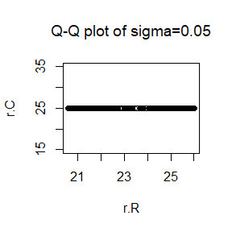

```r
#random numbers from R
rw1.R <- rw.Metropolis( sigma[1], x0, N)
rw2.R <- rw.Metropolis( sigma[2], x0, N)
rw3.R <- rw.Metropolis( sigma[3], x0, N)
rw4.R <- rw.Metropolis( sigma[4], x0, N)
#random numbers from Rcpp
rw1.C <- randomwalkC( sigma[1], x0, N)
rw2.C <- randomwalkC( sigma[2], x0, N)
rw3.C <- randomwalkC( sigma[3], x0, N)
rw4.C <- randomwalkC( sigma[4], x0, N)
#effective rw
r1.R <- rw1.R[rw1.R[,2]==1,1]; r1.C <- rw1.C[rw1.C[,2]==1,1]
r2.R <- rw2.R[rw2.R[,2]==1,1]; r2.C <- rw2.C[rw2.C[,2]==1,1]
r3.R <- rw3.R[rw3.R[,2]==1,1]; r3.C <- rw3.C[rw3.C[,2]==1,1]
r4.R <- rw4.R[rw4.R[,2]==1,1]; r4.C <- rw4.C[rw4.C[,2]==1,1]
#qqplot
qqplot(r1.R, r1.C, xlab = "r.R",ylab = "r.C",main = expression("Q-Q plot of sigma=0.05" ))
```

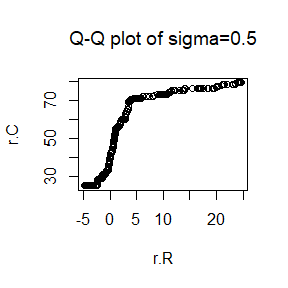

```r
qqplot(r2.R, r2.C, xlab = "r.R",ylab = "r.C",main = expression("Q-Q plot of sigma=0.5"  ))
```

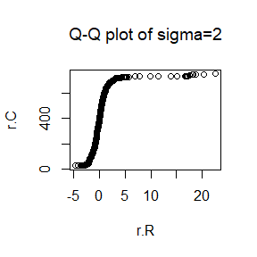

```r
qqplot(r3.R, r3.C, xlab = "r.R",ylab = "r.C",main = expression("Q-Q plot of sigma=2"    ))
```

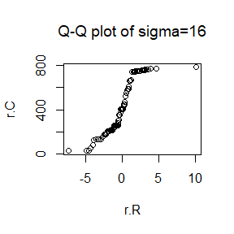

```r
qqplot(r4.R, r4.C, xlab = "r.R",ylab = "r.C",main = expression("Q-Q plot of sigma=16"   ))
```

### Campare the computation time of the two functions with microbenchmark

```r
library(microbenchmark)
ts <- microbenchmark(rw1.R <- rw.Metropolis(sigma[1], x0, N) ,rw2.R <- rw.Metropolis(sigma[2], x0, N) ,rw3.R <- rw.Metropolis(sigma[3], x0, N) ,rw4.R <- rw.Metropolis(sigma[4], x0, N) ,rw1.C <- randomwalkC(sigma[1], x0, N) ,rw2.C <- randomwalkC(sigma[2], x0, N) ,rw3.C <- randomwalkC(sigma[3], x0, N)  ,rw4.C <- randomwalkC(sigma[4], x0, N))
summary(ts)[,c(1,3,5,6)]
```

```
##                                      expr      lq  median      uq
## 1 rw1.R <- rw.Metropolis(sigma[1], x0, N) 8084.50 8408.85 8988.10
## 2 rw2.R <- rw.Metropolis(sigma[2], x0, N) 8125.25 8457.10 9369.75
## 3 rw3.R <- rw.Metropolis(sigma[3], x0, N) 8124.60 8448.40 9193.90
## 4 rw4.R <- rw.Metropolis(sigma[4], x0, N) 8133.45 8435.40 9116.65
## 5   rw1.C <- randomwalkC(sigma[1], x0, N)  394.25  405.20  436.55
## 6   rw2.C <- randomwalkC(sigma[2], x0, N)  411.45  431.00  462.75
## 7   rw3.C <- randomwalkC(sigma[3], x0, N)  362.50  380.40  416.25
## 8   rw4.C <- randomwalkC(sigma[4], x0, N)  258.00  267.85  288.65
```